# Intensity of degree adverbs

Hypothesis: adverbs of degree, like “somewhat” and “extremely”, modify the adjectives they describe in proportion to the cost of uttering them. For example, if “inordinately” is more costly to utter than “very”, the former will have a stronger meaning than the latter.

This cost might manifest in syllable length or in surprisal (how unlikely is that word to be said?).

## Experiment 1: intensifiers

In Experiment 1, I check whether there is any correlation between surprisal/syllable length and strength of an intensifying degree adverb.

I use Google Ngrams data to get the surprisal of each degree adverb. I ran an experiment asking participants the prices of different “*[adverb]* expensive” watches, laptops, and coffee makers. Prices were elicited with free response, and trials looked like this:

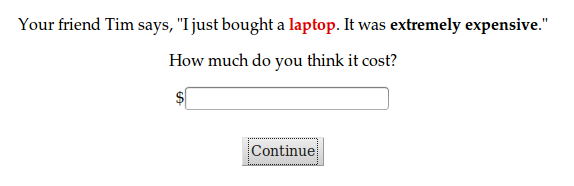

I found that different participants (denoted by the variable `workerid`) gave very different kinds of prices, so in my analysis, I z-scored all responses. Because every pariticpant saw every combination of intensifier and item, this will standardize participants’ responses.

```
## Analysis of Variance Table
##
## Response: price
##                            Df   Sum Sq  Mean Sq F value Pr(>F)
## intensifier                16 4.35e+10 2.72e+09    0.58 0.9006
## item                        2 1.08e+10 5.38e+09    1.15 0.3188
## workerid                   39 3.43e+11 8.81e+09    1.87 0.0013 **
## intensifier:item           32 1.10e+11 3.43e+09    0.73 0.8613
## intensifier:workerid      624 1.62e+12 2.60e+09    0.55 1.0000
## item:workerid              78 2.12e+11 2.72e+09    0.58 0.9984
## intensifier:item:workerid 664 9.57e+11 1.44e+09    0.31 1.0000
## Residuals                 584 2.74e+12 4.70e+09
## ---
## Signif. codes:  0 '***' 0.001 '**' 0.01 '*' 0.05 '.' 0.1 ' ' 1
```

```
## Analysis of Variance Table
##
## Response: zprice
##                            Df Sum Sq Mean Sq F value Pr(>F)
## intensifier                16     93       6   28.72 <2e-16 ***
## item                        2   1042     521 2562.66 <2e-16 ***
## workerid                   39      0       0    0.00    1.0
## intensifier:item           32     34       1    5.26 <2e-16 ***
## intensifier:workerid      624    296       0    2.33 <2e-16 ***
## item:workerid              78    266       3   16.80 <2e-16 ***
## intensifier:item:workerid 664    149       0    1.11    0.1
## Residuals                 584    119       0
## ---
## Signif. codes:  0 '***' 0.001 '**' 0.01 '*' 0.05 '.' 0.1 ' ' 1
```

Z-scored prices seem to depend on the item (naturally some items are more expensive than others) and on surprisal (more surprising degree adverbs tend to have stronger meanings). There appears to be an interaction between surprisal and number of syllables, as well.

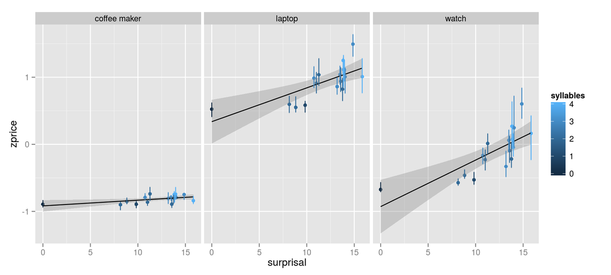

```
## Analysis of Variance Table
##
## Response: zprice
##                            Df Sum Sq Mean Sq F value  Pr(>F)
## surprisal                   1     55      55  128.53 < 2e-16 ***
## syllables                   1      1       1    2.01  0.1567
## item                        2   1046     523 1216.65 < 2e-16 ***
## surprisal:syllables         1      4       4    9.72  0.0018 **
## surprisal:item              2     18       9   21.51 5.7e-10 ***
## syllables:item              2      1       0    1.10  0.3335
## surprisal:syllables:item    2      3       2    3.64  0.0264 *
## Residuals                2028    871       0
## ---
## Signif. codes:  0 '***' 0.001 '**' 0.01 '*' 0.05 '.' 0.1 ' ' 1
```

```
##
## Call:
## lm(formula = zprice ~ surprisal * syllables * item, data = intensifiers)
##
## Coefficients:
##                    (Intercept)                       surprisal
##                      -0.908085                        0.001847
##                      syllables                      itemlaptop
##                       0.024463                        1.375136
##                      itemwatch             surprisal:syllables
##                       0.194021                        0.000157
##           surprisal:itemlaptop             surprisal:itemwatch
##                       0.016377                        0.037065
##           syllables:itemlaptop             syllables:itemwatch
##                      -0.068775                       -0.254495
## surprisal:syllables:itemlaptop   surprisal:syllables:itemwatch
##                       0.010563                        0.021942
```

There is an interaction between the effect of surprisal and the item, so I tried z-scoring within items as well as within workers (variable `zzprice`), which mostly washes out the correlation betweens surprisal and strength of degree adverb. Possibly this is because we are losing information about how participants use the scale when we only look at their behavior on one item at a time.

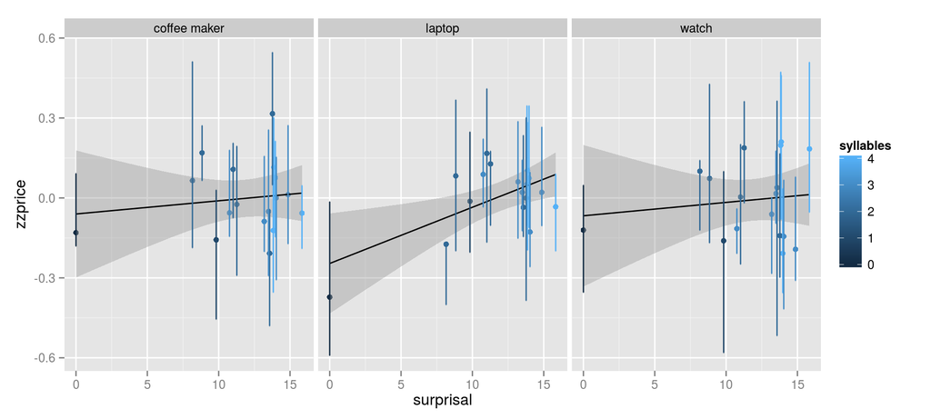

```
## Analysis of Variance Table
##
## Response: zzprice
##                            Df Sum Sq Mean Sq F value Pr(>F)
## surprisal                   1      2   2.358    2.50  0.114
## syllables                   1      1   0.603    0.64  0.424
## item                        2      0   0.041    0.04  0.958
## surprisal:syllables         1      3   2.921    3.10  0.078 .
## surprisal:item              2      1   0.599    0.64  0.530
## syllables:item              2      1   0.393    0.42  0.659
## surprisal:syllables:item    2      1   0.354    0.38  0.687
## Residuals                1977   1863   0.943
## ---
## Signif. codes:  0 '***' 0.001 '**' 0.01 '*' 0.05 '.' 0.1 ' ' 1
```

```
##
## Call:
## lm(formula = zzprice ~ surprisal * syllables * item, data = intensifiers)
##
## Coefficients:
##                    (Intercept)                       surprisal
##                       -0.13330                         0.00837
##                      syllables                      itemlaptop
##                        0.12254                        -0.23631
##                      itemwatch             surprisal:syllables
##                        0.03808                        -0.00839
##           surprisal:itemlaptop             surprisal:itemwatch
##                        0.01837                        -0.01739
##           syllables:itemlaptop             syllables:itemwatch
##                        0.09961                         0.00836
## surprisal:syllables:itemlaptop   surprisal:syllables:itemwatch
##                       -0.00691                         0.00408
```

Overall, in Experiment 1 I found some evidence that degree adverbs that are less probable in a corpus tend to have stronger meanings. If there really is such a correlation, it is unclear whether the surprisal of the word causes the meaning. Possibly events that are more extreme are less common in the world and therefore are talked about less (this seems somewhat unlikely given that people are more likely to comment on unusual events than to comment on ordinary events, but it is possible). If this were the case, then we would find a correlation between surprisal and strength of degree adverbs, but this would not give us much information about how the meanings of those degree adverbs come to be. In order to resolve this confound, I ran Experiment 2.

## Experiment 2

In Experiment 2, I used degree adverbs that modified adjectives in the opposite direction from the intensifiers of Experiment 1. I used “deintensifying” degree adverbs like “somwhat” and “moderately”, which have stronger meanings when they describe more ordinary objects. For example, a “somewhat expensive watch” would have a more ordinary price than an “expensive watch”.

If more ordinary objects are talked about more, and this is what drives the correlation between surprisal and degree in Experiment 1, then less strong deintensifiers (those that correspond to higher prices) should be less common in a corpus and therefore have higher surprisal values.

However, if the strength of a degree adverb is greater as a result of it being less commonly used, then stronger deintensifiers (those that correspond to lower prices) should be less common in a corpus.

Using prices z-scored by participant, I found a negative relationship between surprisal (I’m using negative log frequency instead of negative log probability here because I don’t have access to the total number of 2-grams and some of my deintensifiers were 2-grams) and responses. This provides evidence for the hypothesis that the improbability of a degree adverb might be the source of its strength.

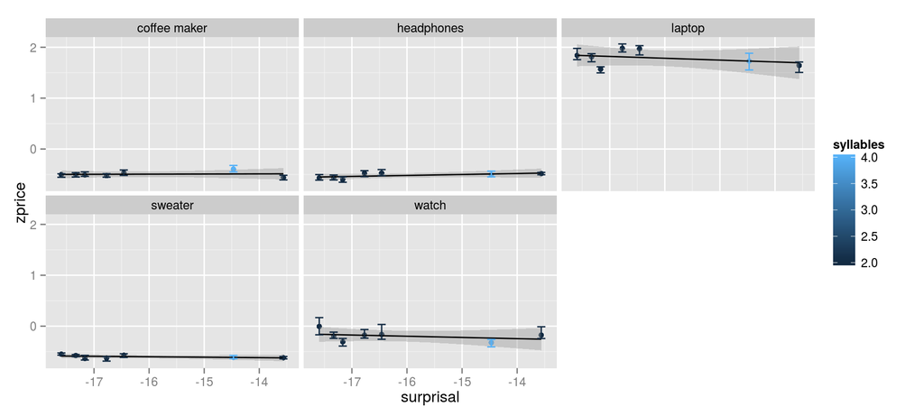

```
## Analysis of Variance Table
##
## Response: zprice
##                  Df Sum Sq Mean Sq F value  Pr(>F)
## surprisal         1      3     2.7   20.79 5.6e-06 ***
## syllables         1      0     0.1    0.40   0.527
## item              4   1137   284.3 2186.68 < 2e-16 ***
## surprisal:item    4      1     0.3    1.96   0.099 .
## syllables:item    4      1     0.3    1.93   0.103
## Residuals      1357    176     0.1
## ---
## Signif. codes:  0 '***' 0.001 '**' 0.01 '*' 0.05 '.' 0.1 ' ' 1
```

```
##
## Call:
## lm(formula = zprice ~ surprisal * syllables * item, data = deintensifiers)
##
## Coefficients:
##                        (Intercept)                           surprisal
##                           -0.89023                            -0.01428
##                          syllables                      itemheadphones
##                            0.07169                             0.74065
##                         itemlaptop                         itemsweater
##                            2.14297                             0.13940
##                          itemwatch                 surprisal:syllables
##                            0.74002                                  NA
##           surprisal:itemheadphones                surprisal:itemlaptop
##                            0.03586                            -0.02030
##              surprisal:itemsweater                 surprisal:itemwatch
##                            0.00505                             0.00742
##           syllables:itemheadphones                syllables:itemlaptop
##                           -0.08243                            -0.07770
##              syllables:itemsweater                 syllables:itemwatch
##                           -0.07057                            -0.14015
## surprisal:syllables:itemheadphones      surprisal:syllables:itemlaptop
##                                 NA                                  NA
##    surprisal:syllables:itemsweater       surprisal:syllables:itemwatch
##                                 NA                                  NA
```

Again, I do not find this effect when I z-score by both participant and item.

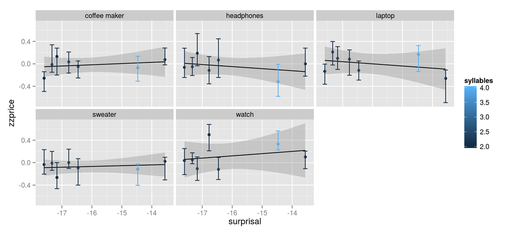

```
## Analysis of Variance Table
##
## Response: zzprice
##                  Df Sum Sq Mean Sq F value Pr(>F)
## surprisal         1      0   0.002    0.00  0.959
## syllables         1      0   0.001    0.00  0.968
## item              4      6   1.395    1.63  0.164
## surprisal:item    4      3   0.745    0.87  0.480
## syllables:item    4      8   1.918    2.24  0.062 .
## Residuals      1357   1160   0.855
## ---
## Signif. codes:  0 '***' 0.001 '**' 0.01 '*' 0.05 '.' 0.1 ' ' 1
```

```
##
## Call:
## lm(formula = zzprice ~ surprisal * syllables * item, data = deintensifiers)
##
## Coefficients:
##                        (Intercept)                           surprisal
##                             0.7379                              0.0375
##                          syllables                      itemheadphones
##                            -0.0663                             -0.4094
##                         itemlaptop                         itemsweater
##                            -2.4404                             -0.2600
##                          itemwatch                 surprisal:syllables
##                            -0.6362                                  NA
##           surprisal:itemheadphones                surprisal:itemlaptop
##                            -0.0378                             -0.1180
##              surprisal:itemsweater                 surprisal:itemwatch
##                            -0.0112                             -0.0228
##           syllables:itemheadphones                syllables:itemlaptop
##                            -0.0962                              0.2432
##              syllables:itemsweater                 syllables:itemwatch
##                             0.0129                              0.1768
## surprisal:syllables:itemheadphones      surprisal:syllables:itemlaptop
##                                 NA                                  NA
##    surprisal:syllables:itemsweater       surprisal:syllables:itemwatch
##                                 NA                                  NA
```

# Experiment 3

In Experiment 3, I replicated my findings from Experiments 1 and 2 on a new set of degree adverbs.

With responses z-scored by participant, I find a positive relationship between surprisal and response for intensifiers.

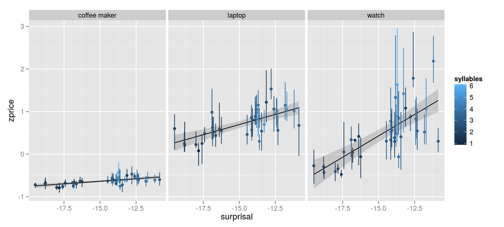

```
## Analysis of Variance Table
##
## Response: zprice
##                            Df Sum Sq Mean Sq F value  Pr(>F)
## surprisal                   1     68    68.3   99.20 < 2e-16 ***
## syllables                   1      5     5.2    7.55  0.0061 **
## item                        2    401   200.7  291.70 < 2e-16 ***
## surprisal:syllables         1      0     0.3    0.49  0.4828
## surprisal:item              2     32    15.9   23.06 1.5e-10 ***
## syllables:item              2      5     2.4    3.42  0.0329 *
## surprisal:syllables:item    2      1     0.4    0.61  0.5416
## Residuals                1128    776     0.7
## ---
## Signif. codes:  0 '***' 0.001 '**' 0.01 '*' 0.05 '.' 0.1 ' ' 1
```

```
##
## Call:
## lm(formula = zprice ~ surprisal * syllables * item, data = intensifiers)
##
## Coefficients:
##                    (Intercept)                       surprisal
##                       -0.35332                         0.02246
##                      syllables                      itemlaptop
##                       -0.00764                         3.26997
##                      itemwatch             surprisal:syllables
##                        2.19627                        -0.00181
##           surprisal:itemlaptop             surprisal:itemwatch
##                        0.13406                         0.10849
##           syllables:itemlaptop             syllables:itemwatch
##                       -0.38089                         0.25053
## surprisal:syllables:itemlaptop   surprisal:syllables:itemwatch
##                       -0.02825                         0.00555
```

Although I find a negative relationship between surprisal and response for deintensifiers, this relationship is nonsignificant.

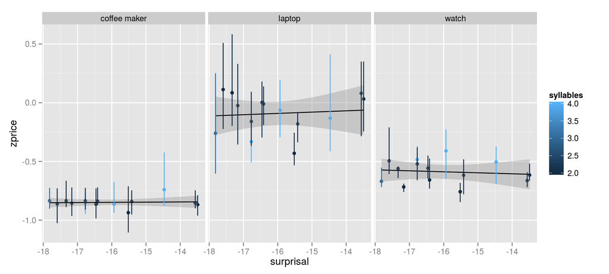

```
## Analysis of Variance Table
##
## Response: zprice
##                           Df Sum Sq Mean Sq F value Pr(>F)
## surprisal                  1    0.0    0.00    0.01  0.928
## syllables                  1    0.0    0.01    0.05  0.823
## item                       2   41.4   20.70  106.65 <2e-16 ***
## surprisal:syllables        1    0.3    0.33    1.69  0.195
## surprisal:item             2    0.0    0.02    0.13  0.882
## syllables:item             2    1.0    0.48    2.46  0.087 .
## surprisal:syllables:item   2    0.1    0.03    0.15  0.865
## Residuals                408   79.2    0.19
## ---
## Signif. codes:  0 '***' 0.001 '**' 0.01 '*' 0.05 '.' 0.1 ' ' 1
```

```
##
## Call:
## lm(formula = zprice ~ surprisal * syllables * item, data = deintensifiers)
##
## Coefficients:
##                    (Intercept)                       surprisal
##                       -1.72081                        -0.05190
##                      syllables                      itemlaptop
##                        0.37981                         0.17427
##                      itemwatch             surprisal:syllables
##                        0.04412                         0.02269
##           surprisal:itemlaptop             surprisal:itemwatch
##                       -0.05138                        -0.00596
##           syllables:itemlaptop             syllables:itemwatch
##                        0.32123                         0.01730
## surprisal:syllables:itemlaptop   surprisal:syllables:itemwatch
##                        0.02605                        -0.00194
```

As in Experiments 1 and 2, I do not find significant relationships between surprisal and response when I z-score by both participant and item.

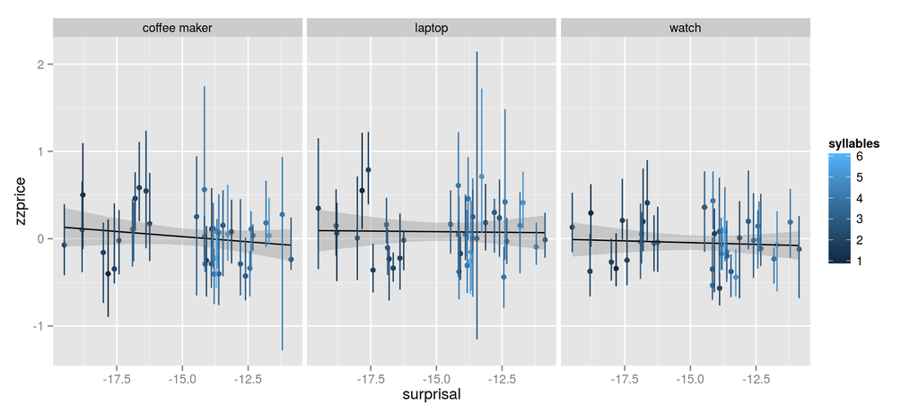

```
## Analysis of Variance Table
##
## Response: zzprice
##                            Df Sum Sq Mean Sq F value Pr(>F)
## surprisal                   1      1   0.790    0.77   0.38
## syllables                   1      0   0.043    0.04   0.84
## item                        2      3   1.542    1.50   0.22
## surprisal:syllables         1      1   0.989    0.96   0.33
## surprisal:item              2      0   0.235    0.23   0.80
## syllables:item              2      0   0.022    0.02   0.98
## surprisal:syllables:item    2      1   0.261    0.25   0.78
## Residuals                1128   1163   1.031
```

```
##
## Call:
## lm(formula = zzprice ~ surprisal * syllables * item, data = intensifiers)
##
## Coefficients:
##                    (Intercept)                       surprisal
##                       -0.65319                        -0.04575
##                      syllables                      itemlaptop
##                        0.12975                        -0.58893
##                      itemwatch             surprisal:syllables
##                        0.21582                         0.00925
##           surprisal:itemlaptop             surprisal:itemwatch
##                       -0.04075                         0.02039
##           syllables:itemlaptop             syllables:itemwatch
##                        0.34456                        -0.03347
## surprisal:syllables:itemlaptop   surprisal:syllables:itemwatch
##                        0.02313                        -0.00284
```

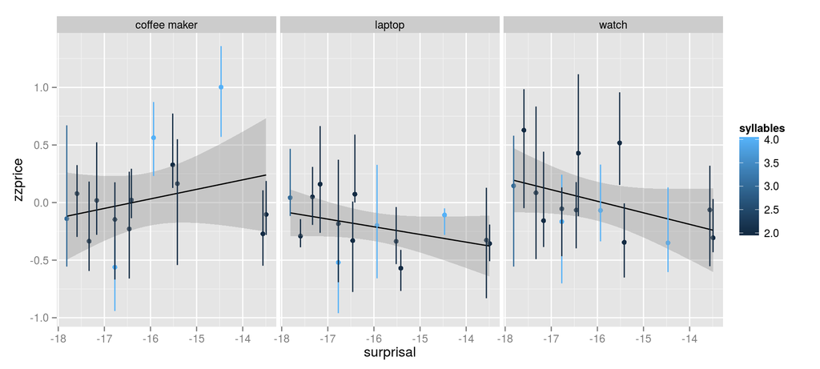

```
## Analysis of Variance Table
##
## Response: zzprice
##                           Df Sum Sq Mean Sq F value Pr(>F)
## surprisal                  1      1    0.61    0.76  0.383
## syllables                  1      0    0.05    0.07  0.796
## item                       2      5    2.45    3.09  0.047 *
## surprisal:syllables        1      5    5.16    6.51  0.011 *
## surprisal:item             2      5    2.44    3.07  0.048 *
## syllables:item             2      4    2.10    2.64  0.073 .
## surprisal:syllables:item   2      5    2.40    3.02  0.050 *
## Residuals                408    324    0.79
## ---
## Signif. codes:  0 '***' 0.001 '**' 0.01 '*' 0.05 '.' 0.1 ' ' 1
```

```
##
## Call:
## lm(formula = zzprice ~ surprisal * syllables * item, data = deintensifiers)
##
## Coefficients:
##                    (Intercept)                       surprisal
##                         -9.598                          -0.581
##                      syllables                      itemlaptop
##                          4.631                           5.230
##                      itemwatch             surprisal:syllables
##                          8.278                           0.281
##           surprisal:itemlaptop             surprisal:itemwatch
##                          0.317                           0.480
##           syllables:itemlaptop             syllables:itemwatch
##                         -3.317                          -4.733
## surprisal:syllables:itemlaptop   surprisal:syllables:itemwatch
##                         -0.197                          -0.280
```